# Clustering and Anomaly Detection

### Part 5: Anomaly Detection

In most real life applications the data observations are subject to noise present either in the environment or the sensor apparatus. Anomaly detection plays a vital role in the preprocessing stage to identify these outliers and optionally remove them from the data set. Anomaly detection algorithms can be broadly classified into 3 classes (see Nicolas Goix's [slides](https://ngoix.github.io/nicolas_goix_osi_presentation.pdf) on anomaly detection):

- Supervised AD (labels available for both normal data and anomalies)
- Semi-supervised AD, also called Novelty Detection (only normal data available to train)
- Unsupervised AD, also called Outlier Detection (no labels are provided)

```python
# loading the datasets
filenames = ['data1.csv', 'data2.csv', 'data3.csv', 'data4.csv']
datasets = [np.loadtxt(fname, delimiter=', ') for fname in filenames]
for fname, data in zip(filenames, datasets):
    print (fname, data.shape)
```

```
data1.csv (445, 2)
data2.csv (314, 2)
data3.csv (419, 2)
data4.csv (441, 2)
```

```python
def plot_all(y_preds):

    print("len(y_preds):", len(y_preds))

    names = ['Robust Covariance', 'Isolation Forest', 'Local Outlier Factor', 'One-Class SVM']
    plt.figure(figsize=(len(names) * 2 + 3, 12.5))
    plt.subplots_adjust(left=.02, right=.98, bottom=.001, top=.96, wspace=.05, hspace=.01)
    plot_num = 1

    for i_dataset in range(len(datasets)):
        for j_algorithm in range(len(names)):

            plt.subplot(len(datasets), len(names), plot_num)
            if i_dataset == 0:
                plt.title(names[j_algorithm], size=18)

            colors = np.array(['#377eb8', '#ff7f00'])
            plt.scatter(datasets[i_dataset][:, 0], datasets[i_dataset][:, 1],
                        s=10, color=colors[(y_preds[plot_num-1] + 1) // 2])

            plt.xlim(-7, 7)
            plt.ylim(-7, 7)
            plt.xticks(())
            plt.yticks(())

            plot_num += 1

    plt.show()
```

[output not shown]

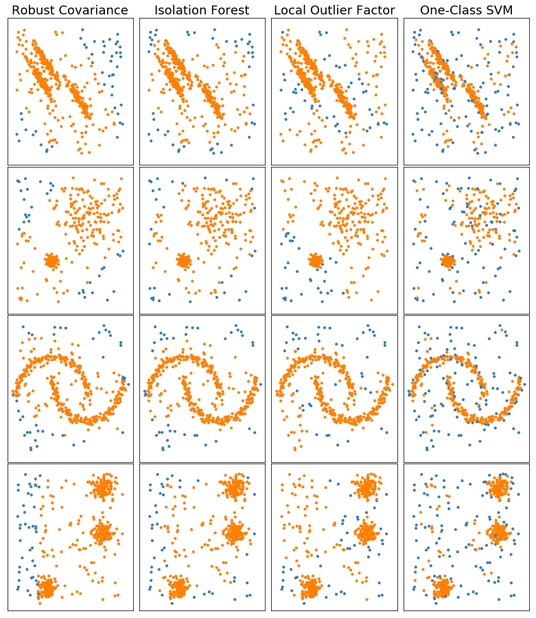

```python
from sklearn.covariance import EllipticEnvelope
from sklearn.ensemble import IsolationForest
from sklearn.neighbors import LocalOutlierFactor
from sklearn.svm import OneClassSVM

outliers_fraction = 0.25

y_pred_list = list()

for X in datasets:
    # apply EllipticEnvelope AD
    # append resulting y_pred to y_pred_list
    e = EllipticEnvelope().fit(X).predict(X)
    y_pred_list.append(e)
    # apply IsolationForest AD
    # append resulting y_pred to y_pred_list
    i = IsolationForest().fit(X).predict(X)
    y_pred_list.append(i)
    # apply LocalOutlierFactor AD
    # append resulting y_pred to y_pred_list
    l = LocalOutlierFactor().fit_predict(X)
    y_pred_list.append(l)
    # apply OneClassSVM AD
    # append resulting y_pred to y_pred_list
    o = OneClassSVM(nu=0.25, kernel='rbf').fit(X).predict(X)
    y_pred_list.append(o)

plot_all(y_pred_list)
```